# Praktikum 5 Anreg

# Library

```r
library(readxl) # untuk membaca data
library(GGally) # untuk menghasilkan matriks hubungan antarpeubah
```

```r
library(corrplot) # untuk menghasilkan matriks korelasi
library(dplyr) # untuk manipulasi data
library(car) # untuk memeriksa multikolinearitas
```

# Data

```r
data <- read_excel("Data Anreg Praktikum.xlsx", sheet = "Data analisis")
# Membersihkan nama kolom dari whitespace/newline
names(data) <- trimws(names(data))
head(data) # menampilkan sekian data awal
```

```
## # A tibble: 6 × 8
##   Provinsi       Kepemilikan_Rumah PDRB_harga_berlaku Consumer_Price_Index   TPT
##   <chr>                      <dbl>              <dbl>                <dbl> <dbl>
## 1 Aceh                        85.2            257502.                 110.  5.64
## 2 Sumatera Utara              73.2           1236194.                 109.  5.32
## 3 Sumatera Barat              73.0            352189.                 109.  5.62
## 4 Riau                        78.7           1201384.                 109.  4.16
## 5 Jambi                       89.4            349663.                 108.  4.26
## 6 Sumatera Sela…              85.9            720205.                 109.  3.69
## # ℹ 3 more variables: Urbanisasi <dbl>, Gini_Ratio <dbl>,
## #   `Rata-rata_Lama_Sekolah` <dbl>
```

```r
str(data)  # menampilkan tipe data setiap peubah
```

```
## tibble [34 × 8] (S3: tbl_df/tbl/data.frame)
##  $ Provinsi              : chr [1:34] "Aceh" "Sumatera Utara" "Sumatera Barat" "Riau" ...
##  $ Kepemilikan_Rumah     : num [1:34] 85.2 73.2 73 78.7 89.4 ...
##  $ PDRB_harga_berlaku    : num [1:34] 257502 1236194 352189 1201384 349663 ...
##  $ Consumer_Price_Index  : num [1:34] 110 109 109 109 108 ...
##  $ TPT                   : num [1:34] 5.64 5.32 5.62 4.16 4.26 3.69 3.41 4.21 4.45 6.45 ...
##  $ Urbanisasi            : num [1:34] 36.2 60.1 54.6 40.7 34.8 38.2 33.5 34.6 59.7 83.8 ...
##  $ Gini_Ratio            : num [1:34] 0.274 0.283 0.28 0.304 0.291 0.298 0.339 0.287 0.214 0.385 ...
##  $ Rata-rata_Lama_Sekolah: num [1:34] 10.42 10.29 10.03 9.8 9.32 ...
```

```r
summary(data) # menampilkan ringkasan data
```

```
##    Provinsi         Kepemilikan_Rumah PDRB_harga_berlaku Consumer_Price_Index
##  Length:34          Min.   :54.54     Min.   :  58978    Min.   :105.4
##  Class :character   1st Qu.:81.83     1st Qu.: 150287    1st Qu.:107.7
##  Mode  :character   Median :85.76     Median : 314638    Median :108.4
##                     Mean   :84.69     Mean   : 687418    Mean   :108.2
##                     3rd Qu.:90.77     3rd Qu.: 744859    3rd Qu.:108.9
##                     Max.   :94.22     Max.   :3926153    Max.   :109.9
##       TPT          Urbanisasi       Gini_Ratio     Rata-rata_Lama_Sekolah
##  Min.   :1.490   Min.   : 23.00   Min.   :0.2140   Min.   : 8.540
##  1st Qu.:3.518   1st Qu.: 36.60   1st Qu.:0.2833   1st Qu.: 9.110
##  Median :4.235   Median : 49.35   Median :0.3110   Median : 9.700
##  Mean   :4.518   Mean   : 51.59   Mean   :0.3237   Mean   : 9.673
##  3rd Qu.:5.545   3rd Qu.: 60.00   3rd Qu.:0.3585   3rd Qu.:10.092
##  Max.   :6.960   Max.   :100.00   Max.   :0.4230   Max.   :11.580
```

Data yang digunakan adalah data dari 34 Provinsi di Indonesia pada Tahun 2024 dengan 1 peubah respon yaitu Persentase Kepemilikan Rumah (Kepemilikan_Rumah) dan 6 peubah penjelas yang seluruhnya bersifat kuantitatif. Peubah tersebut adalah PDRB Harga Berlaku (PDRB_harga_berlaku), Consumer Price Index (Consumer_Price_Index), Tingkat Pengangguran Terbuka (TPT), Persentase Urbanisasi (Urbanisasi), Gini Ratio (Gini_Ratio), dan Rata-rata Lama Sekolah (Rata-rata_Lama_Sekolah).

Untuk mempermudah dalam komputasi, karena peubah Provinsi tidak digunakan dalam pemodelan, maka dapat dihapus. Pada praktikum kali ini seluruh peubah yang digunakan bersifat kuantitatif sehingga dibentuk satu data analisis.

```r
data <- select(data, -Provinsi)
dt <- data
```

# Eksplorasi data

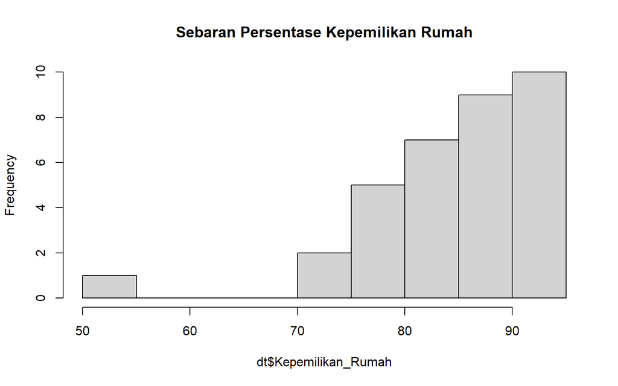

```r
hist(dt$Kepemilikan_Rumah, main = "Sebaran Persentase Kepemilikan Rumah")
```

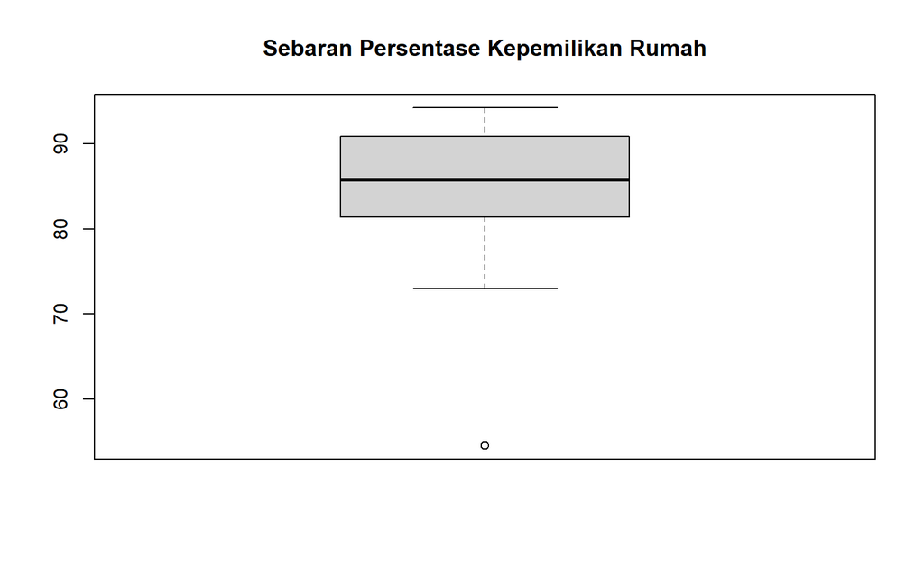

```r
boxplot(dt$Kepemilikan_Rumah, main = "Sebaran Persentase Kepemilikan Rumah")
```

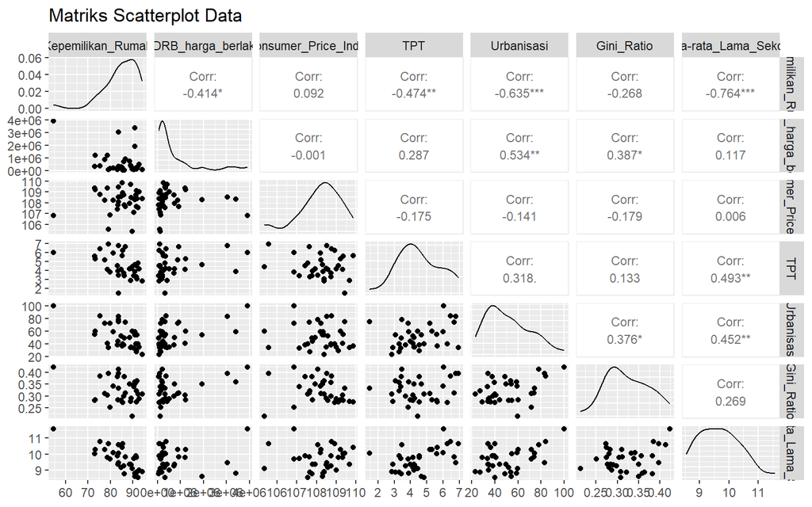

```r
ggpairs(dt,
        upper = list(continuous = wrap('cor', size = 3)),
        title = "Matriks Scatterplot Data")
```

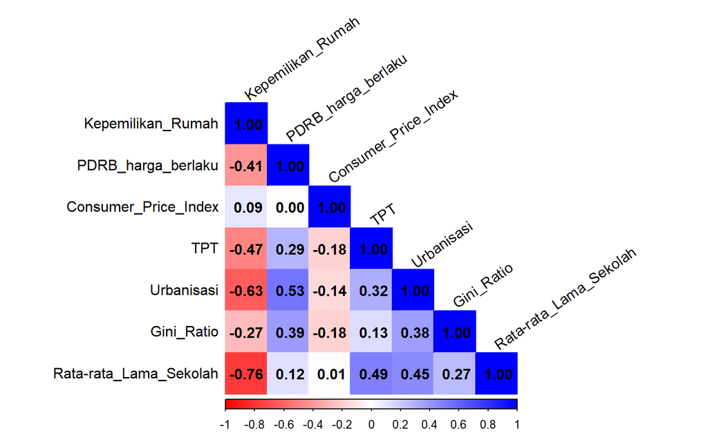

```r
cor_matrix <- cor(dt, use = "complete.obs")

corrplot(cor_matrix, method = "color", type = "lower",
         col = colorRampPalette(c("red", "white", "blue"))(200),
         addCoef.col = "black", tl.col = "black", tl.srt = 35)
```

Korelasi yang tinggi ini mengindikasikan adanya potensi multikolinearitas, yang dapat mempengaruhi keakuratan model yang akan dibentuk.